# Data Input

# Questions

## Decision Tree

### Show the prediction and reasoning of 1-samples in the validation set.

```python
from sklearn import tree
```

```
sample features:
school 1
sex 1
age 18
address 0
famsize 1
Pstatus 1
Medu 1
Fedu 1
Mjob 0
Fjob 2
reason 2
guardian 1
traveltime 2
studytime 2
failures 1
schoolsup 0
famsup 0
paid 0
activities 1
nursery 0
higher 0
internet 0
romantic 0
famrel 4
freetime 4
goout 3
Dalc 2
Walc 3
health 5
absences 2
G1 13
G2 12
predict: 1
```

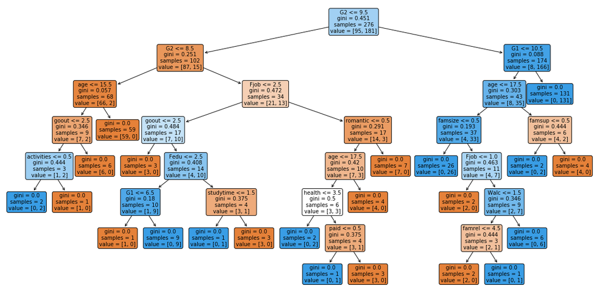

```python
print('sample features:')
for idx, col_name in enumerate(dataset.columns[0:-1]):
    print(col_name, x_test_binary_HV[4][idx])
print('predict:', Y_pred_DT_binary_HV[4])
plt.figure(figsize=(20, 10))
tree.plot_tree(DT_binary_HV, feature_names=dataset.columns[0:-1], fontsize=10, filled=True, rounded=True)
plt.show()
```

## Random Forest

### Describe the difference between boosting and bagging

- Bagging：通常是用在很強的model，抽樣的方法採用bootstrap，從訓練資料中隨機抽取(取出後放回，n<N)樣本訓練多個分類器，抽完即放回重抽所以可能同個資料出現多次。每個分類器的權重一致，最後用投票方式得到最終結果。
- Boosting：通常是用在弱的model，將很多個弱的分類器合成變成一個強分類器，透過將舊分類器的錯誤資料權重提高，然後重新訓練新的分類器，進而降低錯誤率。

## KNN

### Pick 2 features, draw and describe the KNN decision boundaries, You can pick 2 features to re-train the model, or just fix every other feature values.

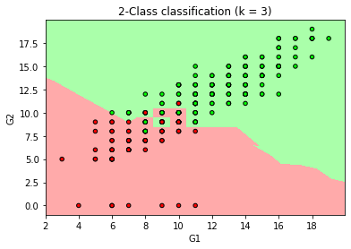

```python
import matplotlib.pyplot as plt
from matplotlib.colors import ListedColormap

x_train = x_train_binary_HV[:, (-2, -1)]
knn = KNN_HV_binary.fit(x_train, y_train_binary_HV)

# step size in the mesh
h = 0.02

# Create color maps
cmap_light = ListedColormap(['#FFAAAA', '#AAFFAA'])
cmap_bold = ListedColormap(['#FF0000', '#00FF00'])

x_min, x_max = x_train[:, 0].min() - 1, x_train[:, 0].max() + 1
y_min, y_max = x_train[:, 1].min() - 1, x_train[:, 1].max() + 1
xx, yy = np.meshgrid(np.arange(x_min, x_max, h), np.arange(y_min, y_max, h))
Z = knn.predict(np.c_[xx.ravel(), yy.ravel()])

# Put the result into a color plot
Z = Z.reshape(xx.shape)
plt.figure()
plt.pcolormesh(xx, yy, Z, cmap=cmap_light)

# Plot also the training points
plt.scatter(x_train[:, 0], x_train[:, 1], c=y_train_binary_HV, cmap=cmap_bold, edgecolor='k', s=20)
plt.xlim(xx.min(), xx.max())
plt.xlabel(dataset.columns[-3])
plt.ylim(yy.min(), yy.max())
plt.ylabel(dataset.columns[-2])
plt.title("2-Class classification (k = 3)")

plt.show()
```

```python
print('sample features:')
for i in [-3, -2]:
    print(dataset.columns[i], x_test_binary_HV[20][i])
print('predict:', Y_pred_DT_binary_HV[20])
```

```
sample features:
G1 8
G2 9
predict: 1
```